# Data cleaning, transformation and Visualisation in R - US Consumer Finance Complaints dataset.

Ali Alhasan

# Introduction:

The dataset titled “US Consumer Finance Complaints” will be analysed for this project and it is published for the public on Kaggle platform. (Refer to link below)

[link] (https://www.kaggle.com/cfpb/us-consumer-finance-complaints)

This dataset had been created by The Consumer Financial Protection Bureau (CFPB) in 2013 and then updated two years ago in 2019. CFPB is an american government regulator agency that is responsible for protecting consumers in the financial sector, which includes banks, debt collectors, securities and exchange institutions and payday lenders. The dataset includes more than 555,000 consumer complaints received by the CFPB between late 2011 - early 2016 from different states around the US and against different products and firms.

# Libraries:

```r
library(tidyverse)
library(data.table)
library(magrittr)
library(ggplot2)
library(timeDate)
library(Hmisc)
library(scales)
library(RColorBrewer)
library(dplyr)
library(DT)
```

# Loading dataset:

```r
setwd("C:\\Users\\Ali\\Desktop\\consumer complaints")
dat <- fread("consumer_complaints.csv")
```

#### Exploring the dataset:

```r
str(dat)
```

```
## Classes 'data.table' and 'data.frame':   555957 obs. of  18 variables:
##  $ date_received               : chr  "08/30/2013" "08/30/2013" "08/30/2013" "08/30/2013" ...
##  $ product                     : chr  "Mortgage" "Mortgage" "Credit reporting" "Student loan" ...
##  $ sub_product                 : chr  "Other mortgage" "Other mortgage" "" "Non-federal student loan" ...
##  $ issue                       : chr  "Loan modification,collection,foreclosure" "Loan servicing, payments, escrow account" "Incorrect information on credit report" "Repaying your loan" ...
##  $ sub_issue                   : chr  "" "" "Account status" "Repaying your loan" ...
##  $ consumer_complaint_narrative: chr  "" "" "" "" ...
##  $ company_public_response     : chr  "" "" "" "" ...
##  $ company                     : chr  "U.S. Bancorp" "Wells Fargo & Company" "Wells Fargo & Company" "Navient Solutions, Inc." ...
##  $ state                       : chr  "CA" "CA" "NY" "MD" ...
##  $ zipcode                     : chr  "95993" "91104" "11764" "21402" ...
##  $ tags                        : chr  "" "" "" "" ...
##  $ consumer_consent_provided   : chr  "" "" "" "" ...
##  $ submitted_via               : chr  "Referral" "Referral" "Postal mail" "Email" ...
##  $ date_sent_to_company        : chr  "09/03/2013" "09/03/2013" "09/18/2013" "08/30/2013" ...
##  $ company_response_to_consumer: chr  "Closed with explanation" "Closed with explanation" "Closed with explanation" "Closed with explanation" ...
##  $ timely_response             : chr  "Yes" "Yes" "Yes" "Yes" ...
##  $ consumer_disputed?          : chr  "Yes" "Yes" "No" "Yes" ...
##  $ complaint_id                : int  511074 511080 510473 510326 511067 510098 511062 511116 511091 530602 ...
##  - attr(*, ".internal.selfref")=<externalptr>
```

The dataset consists of 555957 observations by 18 variables (17 of which are characters and 1 is an integer). We can first notice that the date in the first column is listed in the form of month/day/year (american style) and that should be chnaged to day/month/year.Additionally, for the purpose of clarity, the states column can be rewritten as two columns containing eastern and western states. Likewise, the sybmitted_via column can also have degital submission which includes(email and website). However, we will be looking into that next.

# Data Cleaning and Transformation:

#### Creating quarters using concatenate:

```r
q1 <- c("1","2","3") #refers to quarter one
q2 <- c("4","5","6") #q2 refers to quarter two
q3 <- c("7","8","9") # q3 refers to quarter three
q4 <- c("10","11","12") # q4 refers to quarter four
```

#### Converting states to state regions:

```r
north_east <- c("ME", "VT", "NH", "MA", "CT","RI", "NY", "PA", "NJ")
southern <- c("MD", "DE", "WV", "VA", "NC", "SC", "GA", "FL", "KY","TN", "AL", "MS", "OK", "AR", "LA", "TX")
midwest <- c("WI", "MI", "IL", "IN", "OH", "ND","MN", "SD", "IA","NE", "KS", "MO")
west <- c("MT", "WY", "ID", "NV", "UT", "CO", "AZ", "NM", "WA", "OR", "CA")
```

The North East Region includes: Maine, Vermont, New Hamshire, Massachusetts, Connecticut, Rhode Island, New York, Pennsylvania, New Jersey.

The Southern Region includes: Maryland, Delaware, West Virginia, Virginia, North Carolina, South Carolina, Georgia, Florida, Kentucky, Tennessee, Alabama, Mississippi, Oklahoma, Arkansas, Louisiana, Texas.

The Midwest Region includes: Wisconsin, Michigan, Illinois, Indiana, Ohio, North Dakota, Minnesota, South Dakota, Iowa, Nebraska, Kansas, Missouri.

# Additional Cleaning & Transformation:

```r
dat2 <- dat %>%
  mutate(date_received =  as.Date(date_received, "%m/%d/%Y"),
         date_sent_to_company = as.Date(date_sent_to_company, "%m/%d/%Y")) %>%
  mutate(days_processing = as.numeric(difftime(date_sent_to_company, date_received, units ="days"))) %>%
  filter(days_processing >= 0) %>%
  mutate(year = format(date_received, format="%Y"),     # make year column
         month = as.character(as.numeric(format(date_received, format="%m")))) %>%  # make month column
  mutate(quarter = case_when(month %in% q1 ~ "Q1",
                             month %in% q2 ~ "Q2",
                             month %in% q3 ~ "Q3",
                             month %in% q4 ~ "Q4")) %>%
  group_by(year) %>%
  mutate(number_of_com = n()) %>%
  ungroup() %>%
  mutate(number_of_complaints = as.numeric(length(unique(dat$complaint_id)))) %>%
  mutate(disputed = if_else(`consumer_disputed?` == "Yes", TRUE, FALSE)) %>%
  mutate(consumer_consent_provided = ifelse(consumer_consent_provided =="" | consumer_consent_provided == "Other","Unknown" ,consumer_consent_provided)) %>%
  dplyr::select(- tags, - consumer_complaint_narrative, -company_public_response)  %>% # drop columns
  filter(state %in% north_east | state %in% southern | state %in% midwest | state %in% west ) %>%
  mutate(state_in = case_when(state %in% north_east ~ "The North East Region",
                              state %in% west ~ "The West Region",
                              state %in% midwest ~ "The Midwest Region",
                              state %in% southern ~ "The South Region"))




worst_ten_companies <- sort(table(dat2$company), decreasing = TRUE) [1:10]
```

#### Number of NAs:

```r
apply(is.na(dat2), 2, sum)
```

```
##                date_received                      product
##                            0                            0
##                  sub_product                        issue
##                            0                            0
##                    sub_issue                      company
##                            0                            0
##                        state                      zipcode
##                            0                            0
##    consumer_consent_provided                submitted_via
##                            0                            0
##         date_sent_to_company company_response_to_consumer
##                            0                            0
##              timely_response           consumer_disputed?
##                            0                            0
##                 complaint_id              days_processing
##                            0                            0
##                         year                        month
##                            0                            0
##                      quarter                number_of_com
##                            0                            0
##         number_of_complaints                     disputed
##                            0                            0
##                     state_in
##                            0
```

All columns have no NAs.

#### Number of blank observations:

```r
apply(dat2=="", 2, sum)
```

```
##                date_received                      product
##                           NA                            0
##                  sub_product                        issue
##                       151707                            0
##                    sub_issue                      company
##                       331912                            0
##                        state                      zipcode
##                            0                           10
##    consumer_consent_provided                submitted_via
##                            0                            0
##         date_sent_to_company company_response_to_consumer
##                           NA                            0
##              timely_response           consumer_disputed?
##                            0                            0
##                 complaint_id              days_processing
##                            0                            0
##                         year                        month
##                            0                            0
##                      quarter                number_of_com
##                            0                            0
##         number_of_complaints                     disputed
##                            0                            0
##                     state_in
##                            0
```

We notice here that both “Sub_issue” and “sub_product” columns have many blank observations. These were not transformed as they are not useful for the purposes of this project (include narrative).

#### Calculation of mean, meadian and max days each complaints takes to process by submission method:

```r
tabulation_submitted_via <- dat2 %>%
  group_by(submitted_via) %>%
  summarise(freq = n(),
            mean = mean (days_processing),
            min = min(days_processing),
            max = max(days_processing),
            median = median(days_processing)) %>%
    DT::datatable() %>%
  DT::formatSignif(columns = "mean", digits = 2)


tabulation_submitted_via
```

|  | submitted_via | freq | mean | min | max | median |
| --- | --- | --- | --- | --- | --- | --- |
| 1 | Email | 290 | 8.5448275862069 | 0 | 189 | 2 |
| 2 | Fax | 7772 | 6.80416881111683 | 0 | 287 | 3 |
| 3 | Phone | 38447 | 5.01537181054439 | 0 | 683 | 2 |
| 4 | Postal mail | 35706 | 9.91458018260236 | 0 | 714 | 5 |
| 5 | Referral | 106327 | 6.28155595474339 | 0 | 613 | 3 |
| 6 | Web | 347779 | 3.61351893012516 | 0 | 993 | 0 |

We can notice that the data here is arranged in a frequency ascending order where email is lowest submission method and web is highest. Mean processing days ranges between 3 days to 10 days, where web takes the least time to process and postal mail takes longest. Surprisingly, Web recorded the maximum days to process a complaint of 993 days and Email had the least maximum processing days of 189.

#### Calculation of mean, meadian and max days each complaints takes to process by product:

```r
tabulation_product <- dat2 %>%
  group_by(product) %>%
  summarise(freq = n(),
            mean = mean (days_processing),
            min = min(days_processing),
            max = max(days_processing),
            median = median(days_processing)) %>%
  DT::datatable() %>%
  DT::formatSignif(columns = "mean", digits = 2)
tabulation_product
```

|  | product | freq | mean | min | max | median |
| --- | --- | --- | --- | --- | --- | --- |
| 1 | Bank account or service | 59974 | 3.32020542234969 | 0 | 606 | 1 |
| 2 | Consumer Loan | 20416 | 4.46370493730408 | 0 | 591 | 2 |
| 3 | Credit card | 63582 | 3.10145953257211 | 0 | 993 | 1 |
| 4 | Credit reporting | 88125 | 5.62104964539007 | 0 | 433 | 0 |
| 5 | Debt collection | 97269 | 4.21863080734869 | 0 | 832 | 0 |
| 6 | Money transfers | 3536 | 2.36227375565611 | 0 | 374 | 0 |
| 7 | Mortgage | 181455 | 5.68976330219614 | 0 | 713 | 1 |
| 8 | Other financial service | 534 | 6.53932584269663 | 0 | 95 | 4 |
| 9 | Payday loan | 3775 | 5.01854304635762 | 0 | 352 | 2 |
| 10 | Prepaid card | 2415 | 8.52008281573499 | 0 | 74 | 5 |

[output cut: 1 more lines]

Similar to the table above, this table shows a record of processing time - in days - by the product that has been complained about. We have most complaints here against mortgages followed by debt collection then credit reporting. These top three have a mean days processing of 5.6, 4.2, 5.6 days and maximum processing days of 713, 832 and 433 accordingly.

#### Calculation of mean, meadian and max days each complaints takes to process by year:

```r
tabulation_year <- dat2 %>%
  group_by(year) %>%
  summarise(freq = n(),
            mean = mean (days_processing),
            min = min(days_processing),
            max = max(days_processing),
            median = median(days_processing))  %>%
  DT::datatable() %>%
  DT::formatSignif(columns = "mean", digits = 2)
tabulation_year
```

|  | year | freq | mean | min | max | median |
| --- | --- | --- | --- | --- | --- | --- |
| 1 | 2011 | 2472 | 7.42758899676375 | 0 | 399 | 2 |
| 2 | 2012 | 70789 | 6.75672774018562 | 0 | 993 | 2 |
| 3 | 2013 | 102810 | 7.46241610738255 | 0 | 832 | 1 |
| 4 | 2014 | 145566 | 4.40470989104599 | 0 | 714 | 2 |
| 5 | 2015 | 164984 | 3.17067109537895 | 0 | 352 | 0 |
| 6 | 2016 | 49700 | 1.98472837022133 | 0 | 90 | 0 |

The table above a useful display processing time - in days - by the year. Since this data set did not include the first two quarters of 2011 and the last two quarters of 2016, we do not expect to see many frequency observations for those two years and hence will not disregard in the analysis for this table.

#### Calculations of number of complaints by quarter each year:

```r
tabulation_quarter <- dat2 %>%
  group_by(year, quarter) %>%
  summarise(`Number of Complaint` = n()) %>%
  DT::datatable()
tabulation_quarter
```

|  | year | quarter | Number of Complaint |
| --- | --- | --- | --- |
| 1 | 2011 | Q4 | 2472 |
| 2 | 2012 | Q1 | 12773 |
| 3 | 2012 | Q2 | 20741 |
| 4 | 2012 | Q3 | 18708 |
| 5 | 2012 | Q4 | 18567 |
| 6 | 2013 | Q1 | 25890 |
| 7 | 2013 | Q2 | 23950 |
| 8 | 2013 | Q3 | 27286 |
| 9 | 2013 | Q4 | 25684 |
| 10 | 2014 | Q1 | 35803 |

[output cut: 9 more lines]

# Visualisation & Report Quality:

#### Products vs Year

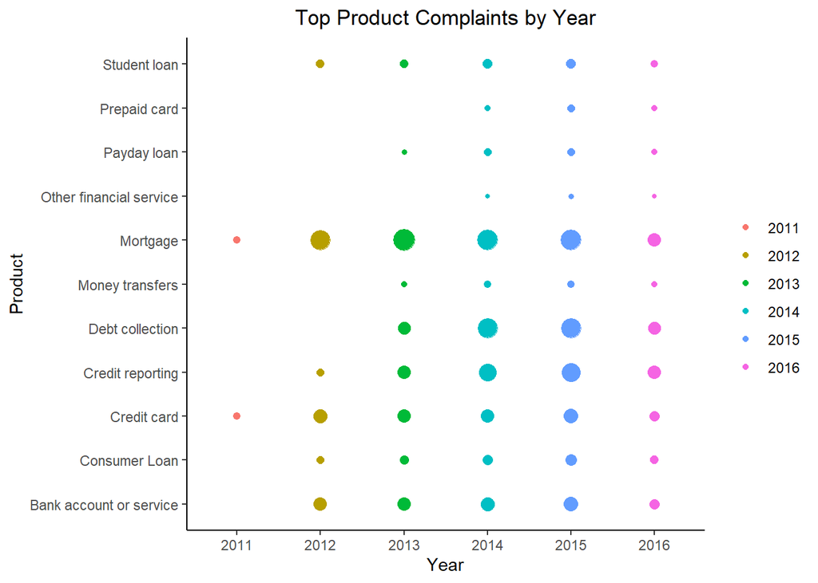

```r
ggplot(dat2, aes(x=dat2$year, y=dat2$product, color = dat2$year)) +
  geom_count(
    mapping = NULL,
    data = NULL,
    stat = "sum",
    position = "identity",
    na.rm = FALSE,
    show.legend = c(size = FALSE),
    inherit.aes = TRUE) +
  theme_classic() +  # theme
  labs(title =  "Top Product Complaints by Year", x = "Year" , y="Product", size ="", color = "") +
  theme(plot.title = element_text(hjust = 0.5))
```

The graph above shows the top product complaints by year. We notice that for all five years, most complaints were in regard to mortgages. Debt collection complaints and Credit Reporting complaints seem to be increasing at a similar rate for years (2013 - 2016). Credit card complaints and Bank Services complaints both increased marginally in 2012. Student loan complaints relatively decresed in 2016.

#### Processing Time in Days VS State Region. (Scaled by Number of Complaints Recieved)

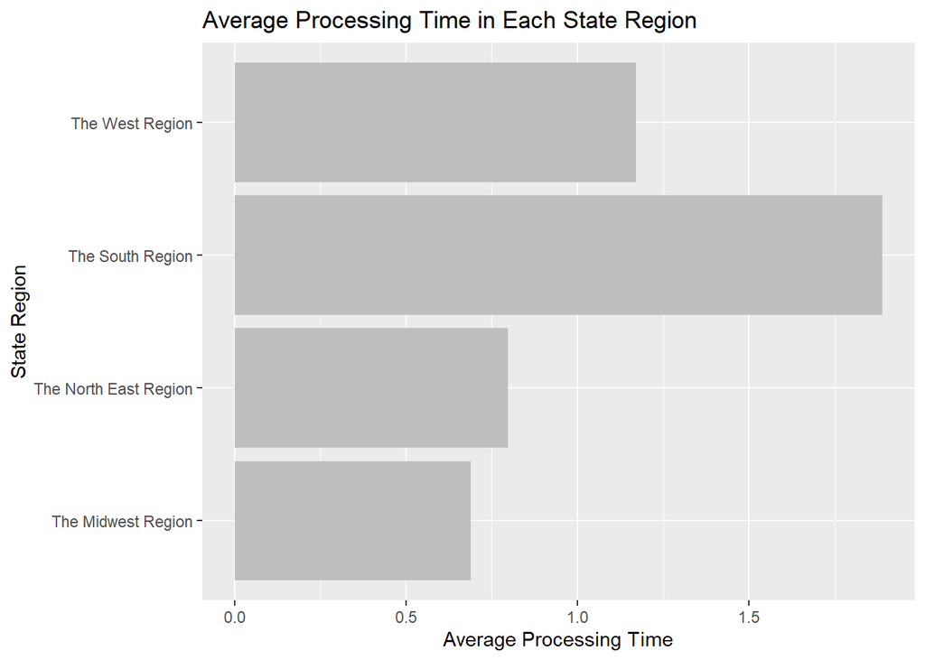

```r
ggplot(dat2, mapping=aes(x=dat2$state_in, y=dat2$days_processing/dat2$number_of_complaints))+
  geom_bar(stat="identity" , fill="gray") +
  coord_flip()+
  labs(title =  "Average Processing Time in Each State Region", x = "State Region" , y="Average Processing Time", size ="")
```

#### Days to Process for every Submission Method.

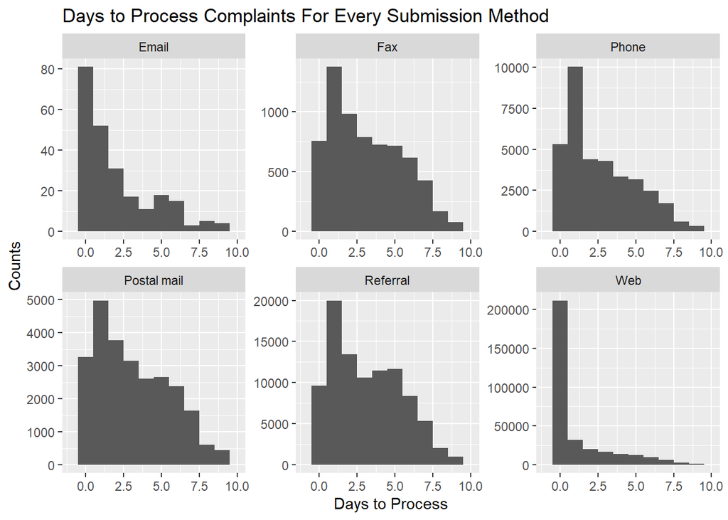

```r
dat2 %>%
  group_by(submitted_via) %>%
  ggplot(aes(days_processing)) +
  geom_histogram(binwidth = 1) +
  xlim(-1,10) +
  facet_wrap(~ submitted_via, scales = "free") +
  labs(title =  "Days to Process Complaints For Every Submission Method", x = "Days to Process" , y="Counts", size ="")
```

The histogram above illustrates the counts of each submission method recieved by the CFPB and the days they took to process. One can first notice that all 6 histograms are skewed to the right. Moreover, The web method processed about 200,000 complaint within the same day. The the referral method handled around 10,000 complaints within the same day, followed by the phone method of 5000 and the postal mail method of nearly 3000, and the fax method of 750 complaints and finally the email method of 80 complaints on the same days.

#### Disputed in State Region

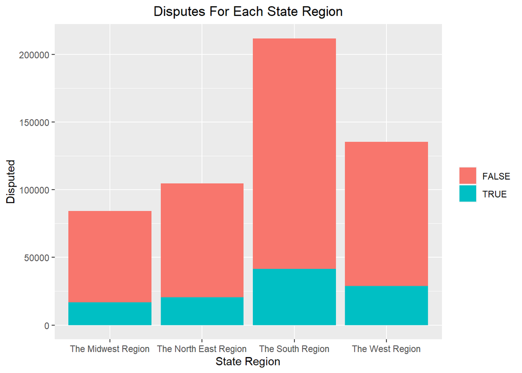

```r
ggplot(dat2, aes(x = dat2$state_in, fill = dat2$disputed)) +
  geom_bar(position = "stack") +
  theme(legend.title = element_blank()) +
  labs(title = "Disputes For Each State Region" , x = "State Region", y= "Disputed") +
  theme(plot.title = element_text(hjust = 0.5))
```

The barplot above shows that most of disputes come from the south region, which also has the highest number of complaints, followed by the west region, the north east region and finally the midwest region.

#### Change in Submission Method by Year

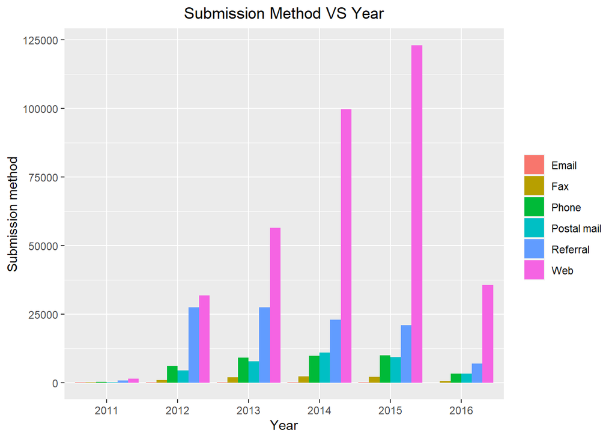

```r
dat2 %>%
  ggplot(mapping = aes(x = dat2$year, fill = dat2$submitted_via)) +
  geom_bar(position = "dodge") +
  theme(legend.title = element_blank()) +
  labs(title = "Submission Method VS Year" , x = "Year", y= "Submission method") +
  theme(plot.title = element_text(hjust = 0.5))
```

The web and referral methods have always been the top two methods for submitting a complaint to the CFPB. The phone method was the third commonly used in 2012 and 2013, however the postal mail method outnumbered it in 2014. Nevertheless, the phone method increased again in 2015 and 2016 to as third.

#### Change in number of Product complaints by Year

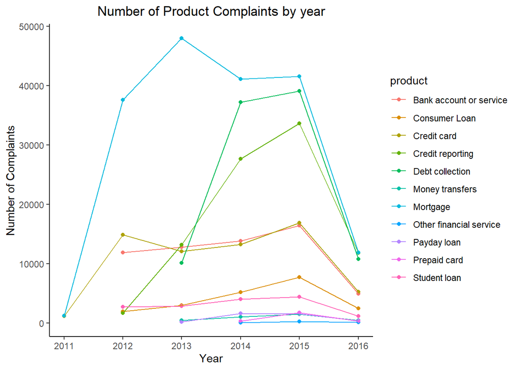

```r
dat2 %>%
  group_by(year, product) %>%
  summarise(total = n()) %>%
  ungroup() %>%
  ggplot(aes(x =as.numeric(year), y= total, color = product )) +
  geom_point()+
  geom_line() +
  theme_classic() +
  ggtitle("Number of Product Complaints by year") +
  xlab("Year") +
  ylab("Number of Complaints") +
  theme(plot.title = element_text(hjust = 0.5))
```

#### Product Complaints by State Region

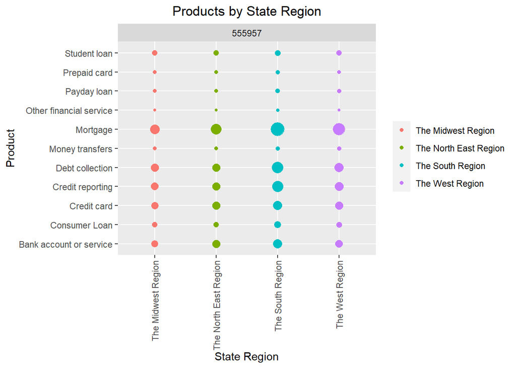

```r
ggplot(dat2, aes(x=dat2$state_in, y=dat2$product, color = dat2$state_in)) +
  geom_count(
    mapping = NULL,
    data = NULL,
    stat = "sum",
    position = "identity",
    na.rm = FALSE,
    show.legend = c(size = FALSE),
    inherit.aes = TRUE) +
  facet_grid(. ~ dat2$number_of_complaints) +
  labs(title =  "Products by State Region", x = "State Region" , y="Product", size ="", color = "") +
  theme(plot.title = element_text(hjust = 0.5)) +
  theme(axis.text.x = element_text(angle = 90, vjust = 0.5, hjust=1))
```

#### Worst Ten Companies by Year Across All States

```r
names(worst_ten_companies)
```

```
##  [1] "Bank of America"
##  [2] "Wells Fargo & Company"
##  [3] "JPMorgan Chase & Co."
##  [4] "Equifax"
##  [5] "Experian"
##  [6] "TransUnion Intermediate Holdings, Inc."
##  [7] "Citibank"
##  [8] "Ocwen"
##  [9] "Capital One"
## [10] "Nationstar Mortgage"
```

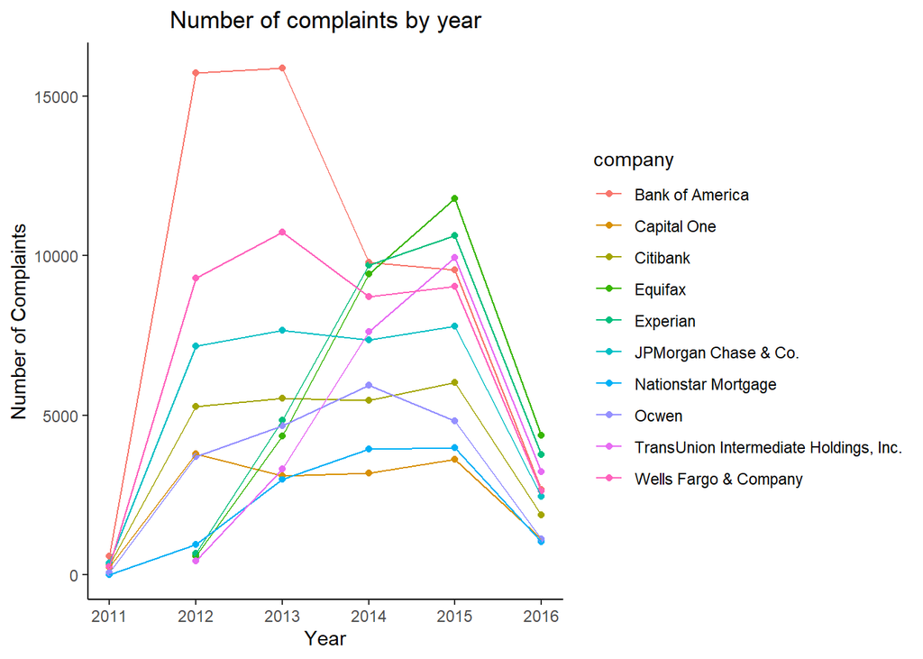

```r
dat2 %>%
  filter(company %in% names(worst_ten_companies) ) %>%
  group_by(year, company) %>%
  summarise(total = n()) %>%
  ungroup() %>%
  ggplot(aes(x =as.numeric(year), y= total, color = company )) +
  geom_point()+
  geom_line() +
  # scale_color_brewer(palette = c("Paired")) +
  theme_classic() +
  ggtitle("Number of complaints by year") +
  xlab("Year") +
  ylab("Number of Complaints") +
  theme(plot.title = element_text(hjust = 0.5))
```

#### Number of complaints of all years

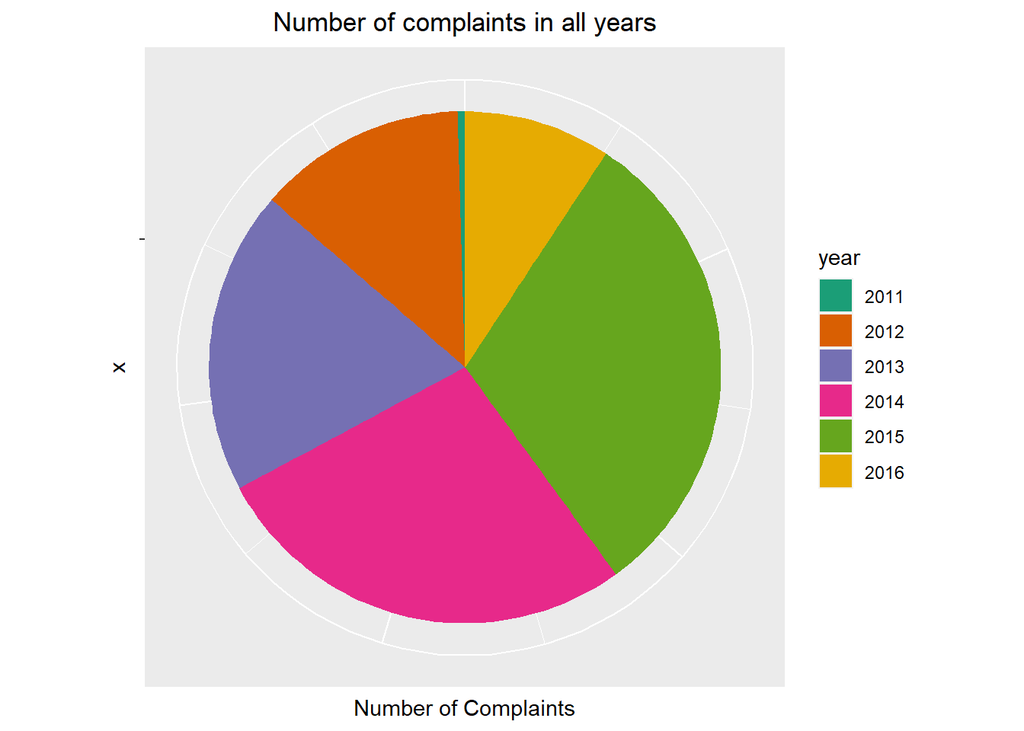

```r
dat2 %>%
  select(year, number_of_com) %>%
  distinct() %>%
  ggplot(aes(x="", y=number_of_com, fill=year))+
  geom_bar(width = 1, stat = "identity") +
  coord_polar("y", start=0) +
  scale_fill_brewer(palette="Dark2") +
  theme(axis.text.x=element_blank()) +
  ggtitle("Number of complaints in all years") +
  ylab("Number of Complaints") +
  theme(plot.title = element_text(hjust = 0.5))
```

The Pie chart graph allows us to split all complaints into years, where all 360 degrees pie chart represents all complaints across all years. We can notice that 2015 documented the highest number of complaints followed by 2014, which recorded approximately the same size. Year 2013 was third and 2012 was fourth, followed by year 2016 and finally 2011 with the least number of complaints.